# Построение дашбордов в Apache Superset

В этом блоке описано построение дашбордов, созданных для визуализации основных метрик приложения, объединяющего ленту новостей и мессенджер.

## 1 Лента новостей - Основной

ссылка на Superset - https://superset.lab.karpov.courses/superset/dashboard/3509/

Данный дашборд отображает основные метрики ленты новостей, с возможностью настраивать срезы с помощью фильтров. Визуализированы следующие метрики:

- Общее число пользователей
- Распределение пользователей по возрастным группам
- Распределение пользователей по городам
- DAU, MAU, WAU
- Лайки и просмотры
- CTR
- Stickiness Ratio
- Топ стран\топ постов\топ пользователей

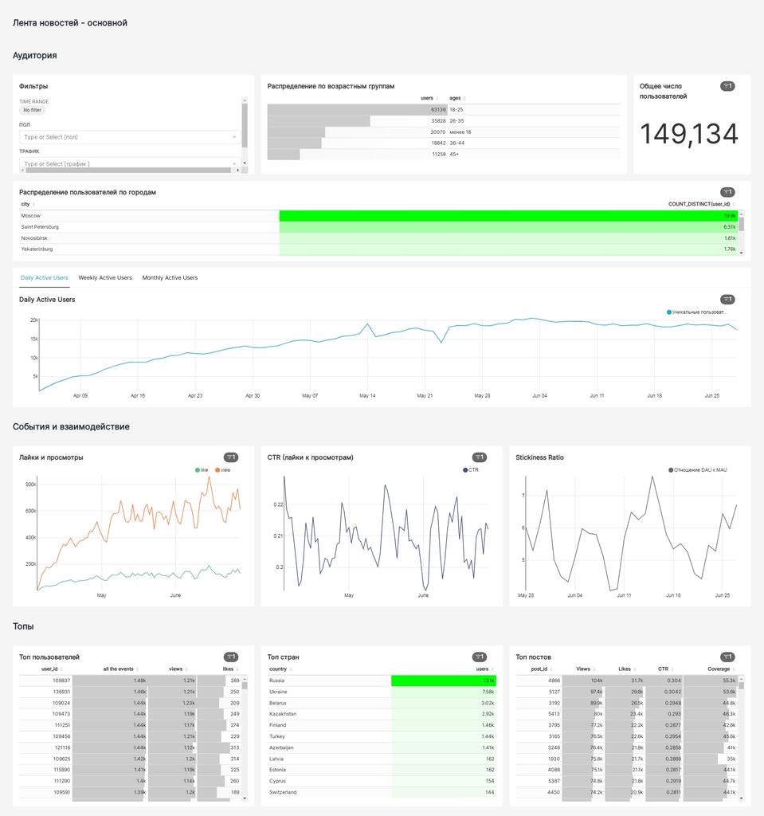

## 2 Лента новостей - Оперативные данные

Данный дашборд отображает основные метрики ленты новостей, которые визуализируют сегодняшний день.

Перечень метрик:

- Все события;
- Количество уникальных пользователей;
- Распределение уникальных пользователей в течении дня со смещением (1 день назад, 1 неделя назад);
- Лайки и просмотры;
- Количество уникальных постов;
- Распределение уникальных постов в течении дня со смещением (1 день назад, 1 неделя назад);
- Топ 10 постов.

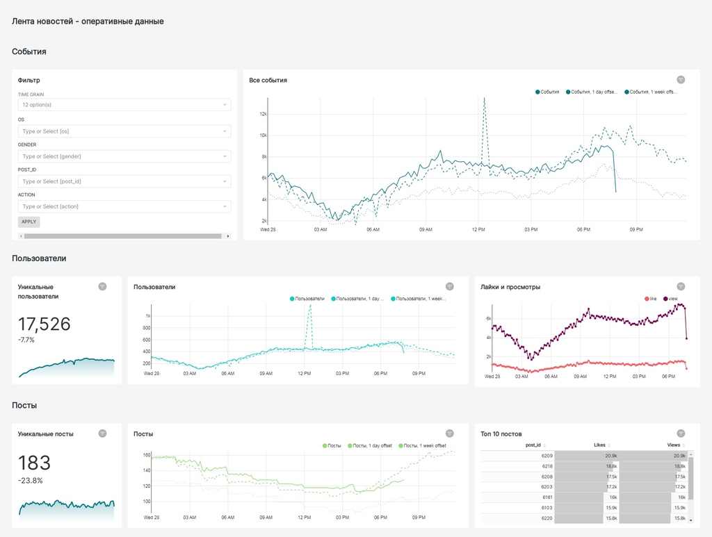

## 2 Взаимодействие сервисов

ссылка на Superset - https://superset.lab.karpov.courses/superset/dashboard/3542/

Данный дашборд отображает взаимодействие двух сервисов приложения: ленты новостей и мессенджера.

Перечень метрик:

- Аудитория приложения;
- Количество уникальных пользователей в ленте новостей сегодня;
- Количество уникальных пользователей в мессенджере сегодня;
- Количество человек не использующих мессенджер;
- Разрез по операционным системам\источникам пользователей;
- Топ 10 наиболее активных пользователей.

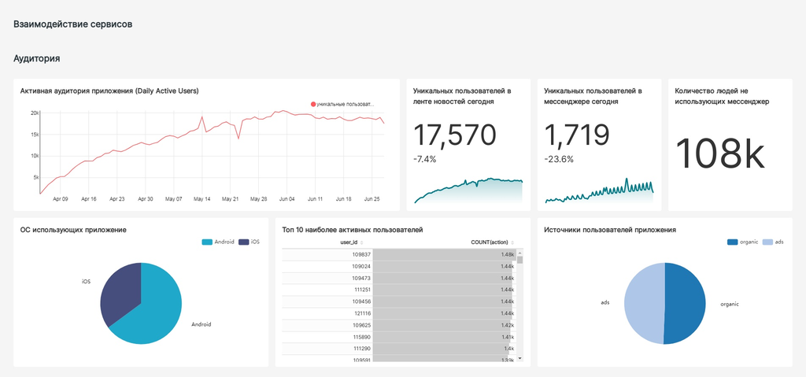